# Biostat 212a Homework 5

Due Mar 20, 2026 @ 11:59PM

Author

Max Vo ; 106784933

## 1 ISL Exercise 9.7.1 (10pts)

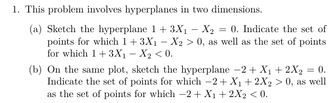

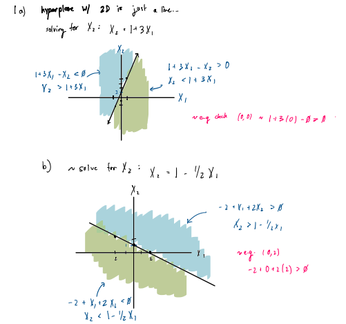

## 2 ISL Exercise 9.7.2 (10pts)

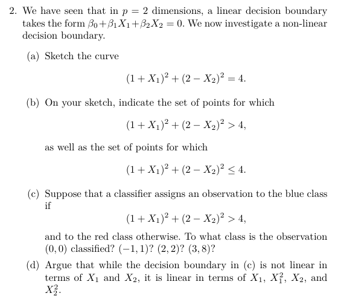

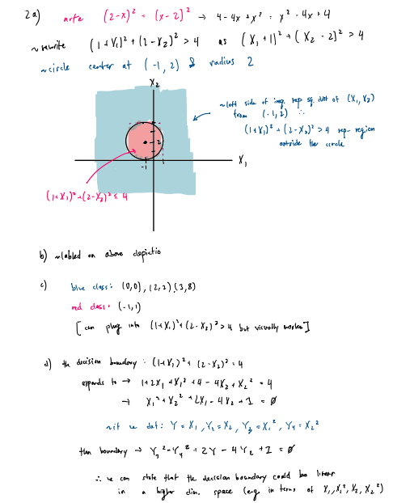

## 3 Support vector machines (SVMs) on the `Carseats` data set (30pts)

Follow the machine learning workflow to train support vector classifier (same as SVM with linear kernel), SVM with polynomial kernel (tune the degree and regularization parameter $C$), and SVM with radial kernel (tune the scale parameter $\gamma$ and regularization parameter $C$) for classifying `Sales<=8` versus `Sales>8`. Use the same seed as in your HW4 for the initial test/train split and compare the final test AUC and accuracy to those methods you tried in HW4.

### 3.1 Libraries/Preprocessing

```r
library(ISLR2)

library(GGally)
library(gtsummary)
library(kernlab) # for SVM
library(tidyverse)
library(tidymodels)
```

```r
Carseats <- Carseats %>%
  mutate(
    Sales_Level = factor(if_else(Sales <= 8, "Low", "High"),
                         levels = c("Low", "High"))
  ) %>%
  select(-Sales) # %>%
  # print(Width = Inf)
```

print out a brief summary

```r
Carseats %>% tbl_summary(by = Sales_Level)
```

| **Characteristic** | **Low** N = 236<sup>1</sup> | **High** N = 164<sup>1</sup> |
| --- | --- | --- |
| CompPrice | 124 (115, 134) | 127 (115, 137) |
| Income | 65 (40, 89) | 76 (58, 95) |
| Advertising | 3.0 (0.0, 10.0) | 10.0 (0.0, 14.0) |
| Population | 268 (132, 391) | 276 (149, 403) |
| Price | 122 (107, 136) | 107 (90, 123) |
| ShelveLoc |  |  |
| Bad | 82 (35%) | 14 (8.5%) |
| Good | 19 (8.1%) | 66 (40%) |
| Medium | 135 (57%) | 84 (51%) |
| Age | 58 (42, 71) | 49 (36, 61) |
| Education |  |  |
| 10 | 23 (9.7%) | 25 (15%) |
| 11 | 31 (13%) | 17 (10%) |
| 12 | 30 (13%) | 19 (12%) |
| 13 | 26 (11%) | 17 (10%) |
| 14 | 26 (11%) | 14 (8.5%) |
| 15 | 18 (7.6%) | 18 (11%) |
| 16 | 29 (12%) | 18 (11%) |
| 17 | 28 (12%) | 21 (13%) |
| 18 | 25 (11%) | 15 (9.1%) |
| Urban | 172 (73%) | 110 (67%) |
| US | 135 (57%) | 123 (75%) |

<sup>1</sup> Median (Q1, Q3); n (%)

```r
# same seed as in HW4
set.seed(321)

Carseats_split <- initial_split(
  Carseats,
  # stratify by Sales_Level
  strata = "Sales_Level",
  prop = 0.75
  )

Carseats_split
```

```
<Training/Testing/Total>
<300/100/400>
```

```r
# verify dim
Carseats_train <- training(Carseats_split)
Carseats_test <- testing(Carseats_split)

dim(Carseats_train)
```

```
[1] 300  11
```

```r
dim(Carseats_test)
```

```
[1] 100  11
```

### 3.2 Specify the recipe

```r
# modification of recipe from workflow

svm_recipe <-
  recipe(
    Sales_Level ~ .,
    data = Carseats
  ) %>%
  # mean imputation for Numeric predictors
  step_impute_mean(all_numeric_predictors()) %>%
  # mode imputation for categorical predictors
  step_impute_mode(all_nominal_predictors()) %>%
  # create traditional dummy variables (necessary for svm)
  step_dummy(all_nominal_predictors()) %>%
  # zero-variance filter
  step_zv(all_numeric_predictors()) %>%
  # center and scale numeric data
  step_normalize(all_predictors())
  # step_novel(all_nominal_predictors())

svm_recipe
```

[output not shown]

### 3.3 Model Specification

```r
# linear SVM
svm_linear_mod <-
  svm_linear(
    mode = "classification",
    cost = tune()
  ) %>%
  set_engine("kernlab")

# polynomial SVM
svm_poly_mod <-
  svm_poly(
    mode = "classification",
    cost = tune(),
    degree = tune()
  ) %>%
  set_engine("kernlab")

# radial SVM
svm_rbf_mod <-
  svm_rbf(
    mode = "classification",
    cost = tune(),
    rbf_sigma = tune()
    # degree = 1
  ) %>%
  set_engine("kernlab")
```

### 3.4 Tuning Grid Specification

```r
# Linear SVM
linear_grid <- grid_regular(
  cost(range = c(-3, 2)),
  levels = 5
)

# Polynomial SVM
poly_grid <- grid_regular(
  cost(range = c(-3, 2)),
  degree(range = c(1, 5)),
  levels = c(5, 5)
)

# Radial SVM
rbf_grid <- grid_regular(
  cost(range = c(-3, 2)),
  rbf_sigma(range = c(-3, 1)),
  levels = c(5, 5)
)
```

### 3.5 Build Workflows

```r
svm_linear_wf <- workflow() %>%
  add_model(svm_linear_mod) %>%
  add_recipe(svm_recipe)

svm_poly_wf <- workflow() %>%
  add_model(svm_poly_mod) %>%
  add_recipe(svm_recipe)

svm_rbf_wf <- workflow() %>%
  add_model(svm_rbf_mod) %>%
  add_recipe(svm_recipe)
```

### 3.6 Cross-validation and Tuning

```r
set.seed(321)
cv <- vfold_cv(Carseats_train, v = 5)
```

### 3.7 Linear SVM Cross Validation + Finalization

```r
svm_linear_fit <- svm_linear_wf %>%
  tune_grid(
    resamples = cv,
    grid = linear_grid,
    metrics = metric_set(roc_auc, accuracy)
  )
```

Visualizing the tuning results

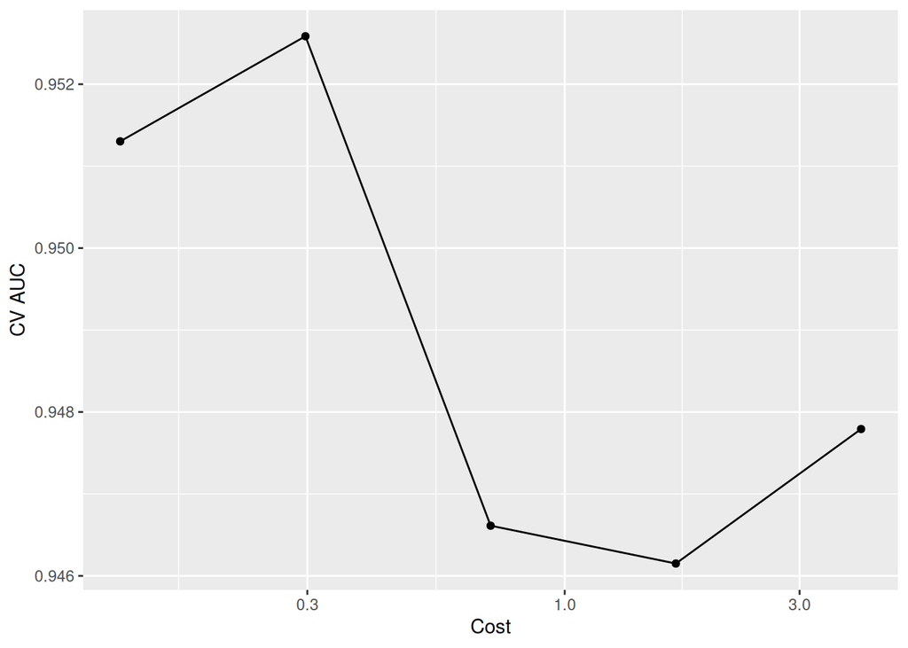

```r
svm_linear_fit %>%
  collect_metrics() %>%
  filter(.metric == "roc_auc") %>%
  ggplot(aes(x = cost, y = mean)) +
  geom_point() +
  geom_line() +
  labs(x = "Cost", y = "CV AUC") +
  scale_x_log10()
```

```r
svm_linear_fit %>%
  show_best(metric = "roc_auc")
```

```
# A tibble: 5 × 7
   cost .metric .estimator  mean     n std_err .config
  <dbl> <chr>   <chr>      <dbl> <int>   <dbl> <chr>
1 0.297 roc_auc binary     0.953     5 0.00780 pre0_mod2_post0
2 0.125 roc_auc binary     0.951     5 0.00712 pre0_mod1_post0
3 4     roc_auc binary     0.948     5 0.0101  pre0_mod5_post0
4 0.707 roc_auc binary     0.947     5 0.00753 pre0_mod3_post0
5 1.68  roc_auc binary     0.946     5 0.00963 pre0_mod4_post0
```

```r
best_linear <- svm_linear_fit %>%
  select_best(metric = "roc_auc")
```

Finalizing workflow with the best hyperparameters

```r
final_linear_wf <- svm_linear_wf %>%
  finalize_workflow(best_linear)

final_linear_wf
```

```
══ Workflow ════════════════════════════════════════════════════════════════════
Preprocessor: Recipe
Model: svm_linear()

── Preprocessor ────────────────────────────────────────────────────────────────
5 Recipe Steps

• step_impute_mean()
• step_impute_mode()
• step_dummy()
• step_zv()
• step_normalize()

── Model ───────────────────────────────────────────────────────────────────────
Linear Support Vector Machine Model Specification (classification)

Main Arguments:
  cost = 0.29730177875068

Computational engine: kernlab
```

Predct on the test set and evaluate

```r
final_linear_fit <-
  final_linear_wf %>%
  last_fit(Carseats_split)

final_linear_fit %>%
  collect_metrics()
```

```
# A tibble: 3 × 4
  .metric     .estimator .estimate .config
  <chr>       <chr>          <dbl> <chr>
1 accuracy    binary        0.89   pre0_mod0_post0
2 roc_auc     binary        0.958  pre0_mod0_post0
3 brier_class binary        0.0757 pre0_mod0_post0
```

### 3.8 Polynomial SVM Cross Validation + Finalization

```r
svm_poly_fit <- svm_poly_wf %>%
  tune_grid(
    resamples = cv,
    grid = poly_grid,
    metrics = metric_set(roc_auc, accuracy)
  )
```

Visualize tuning results

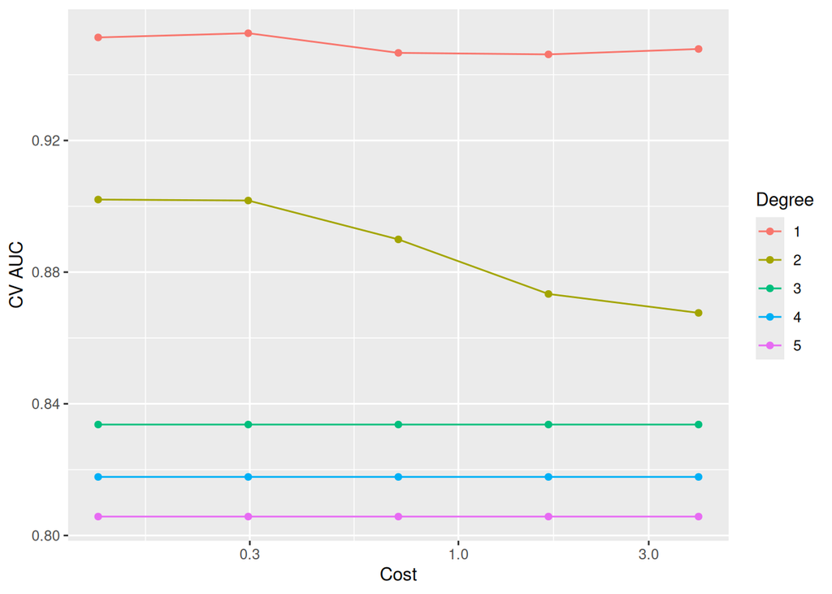

```r
svm_poly_fit %>%
  collect_metrics() %>%
  filter(.metric == "roc_auc") %>%
  ggplot(aes(x = cost, y = mean, color = factor(degree))) +
  geom_point() +
  geom_line() +
  labs(x = "Cost", y = "CV AUC", color = "Degree") +
  scale_x_log10()
```

```r
svm_poly_fit %>%
  show_best(metric = "roc_auc")
```

```
# A tibble: 5 × 8
   cost degree .metric .estimator  mean     n std_err .config
  <dbl>  <dbl> <chr>   <chr>      <dbl> <int>   <dbl> <chr>
1 0.297      1 roc_auc binary     0.953     5 0.00780 pre0_mod06_post0
2 0.125      1 roc_auc binary     0.951     5 0.00712 pre0_mod01_post0
3 4          1 roc_auc binary     0.948     5 0.0101  pre0_mod21_post0
4 0.707      1 roc_auc binary     0.947     5 0.00753 pre0_mod11_post0
5 1.68       1 roc_auc binary     0.946     5 0.00963 pre0_mod16_post0
```

```r
best_poly <- svm_poly_fit %>%
  select_best(metric = "roc_auc")
```

Finalize wf

```r
final_poly_wf <- svm_poly_wf %>%
  finalize_workflow(best_poly)

final_poly_wf
```

```
══ Workflow ════════════════════════════════════════════════════════════════════
Preprocessor: Recipe
Model: svm_poly()

── Preprocessor ────────────────────────────────────────────────────────────────
5 Recipe Steps

• step_impute_mean()
• step_impute_mode()
• step_dummy()
• step_zv()
• step_normalize()

── Model ───────────────────────────────────────────────────────────────────────
Polynomial Support Vector Machine Model Specification (classification)

Main Arguments:
  cost = 0.29730177875068
  degree = 1

Computational engine: kernlab
```

Predict on test set and evaluate

```r
final_poly_fit <- final_poly_wf %>%
  last_fit(Carseats_split)

final_poly_fit %>%
  collect_metrics()
```

```
# A tibble: 3 × 4
  .metric     .estimator .estimate .config
  <chr>       <chr>          <dbl> <chr>
1 accuracy    binary        0.89   pre0_mod0_post0
2 roc_auc     binary        0.958  pre0_mod0_post0
3 brier_class binary        0.0752 pre0_mod0_post0
```